# Final Project

Anthony Wong

12/2/2018

# 1 Favorite Restaurants in Emory Village

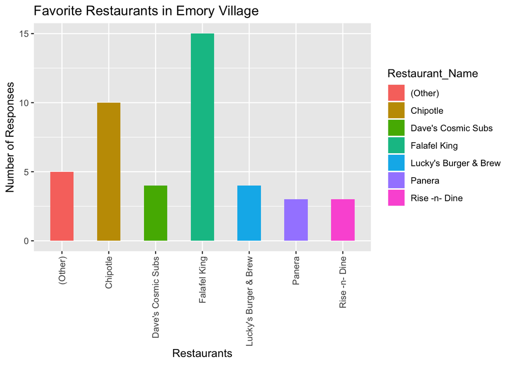

### 1.2.3 Frequency vs Restaurant

```
##
##                         More than once a week Once a month
##   Chipotle                                  1            1
##   Dave's Cosmic Subs                        0            1
##   Falafel King                              0            4
##   Lucky's Burger & Brew                     0            1
##   Panera                                    1            1
##   Rise -n- Dine                             0            1
##   Wagaya                                    0            0
##   Zoës Kitchen                              0            1
##
##                         Once a school year Once a semester Once a week
##   Chipotle                               0               1           1
##   Dave's Cosmic Subs                     0               0           1
##   Falafel King                           0               0           3
##   Lucky's Burger & Brew                  0               0           1
##   Panera                                 0               0           1
##   Rise -n- Dine                          1               0           0
##   Wagaya                                 0               0           2
##   Zoës Kitchen                           0               0           0
##
##                         Once every few months Once every two weeks
##   Chipotle                                  2                    4
##   Dave's Cosmic Subs                        0                    2
##   Falafel King                              2                    6
##   Lucky's Burger & Brew                     1                    1
##   Panera                                    0                    0
##   Rise -n- Dine                             0                    1
##   Wagaya                                    1                    0
##   Zoës Kitchen                              0                    1
```

```
## [1] "Not statistically significant"
```

The p-value of the chisquared test comparing how frequently a respondent goes to Emory village with what their favorite restaurant is, is 0.6432. This meant that **there is no statistically significant relationship between a respondents favorite restaurant and how frequently they go to Emory village.**

### 1.2.4 Job vs Restaurant

```
##
##                         No Yes
##   Chipotle               5   5
##   Dave's Cosmic Subs     3   1
##   Falafel King           5  10
##   Lucky's Burger & Brew  1   3
##   Panera                 1   2
##   Rise -n- Dine          2   1
##   Wagaya                 1   2
##   Zoës Kitchen           1   1
```

```
## [1] "Not statistically significant"
```

The p-value of the chisquared test comparing whether or not the respondent has a job with their favorite restaurant has a p-value of 0.7888. This meant that **there is no statistically significant relationship between whether or not a respondent has a job and what their favorite restaurant is.**

### 1.2.5 Grade vs Restaurant

```
##
##                         First year Junior Senior Sophomore
##   Chipotle                       5      0      1         4
##   Dave's Cosmic Subs             1      1      1         1
##   Falafel King                   4      3      2         6
##   Lucky's Burger & Brew          1      0      0         3
##   Panera                         0      1      0         2
##   Rise -n- Dine                  0      0      1         2
##   Wagaya                         0      2      0         1
##   Zoës Kitchen                   2      0      0         0
```

```
## [1] "Not statistically significant"
```

The p-value of the chisquared test comparing a respondents year in school with their favorite restaurant has a p-value of 0.3595. This meant that **there is no statistically significant relationship between a respondents year in school and their favorite restaurant.**

The data was also broken down to analyze only first year students and non-first year students, repeating the experiments along the two categories. However, even then there was no statistically significant results.

```
##
##              Chipotle    Dave's Cosmic Subs          Falafel King
##                     5                     1                     4
## Lucky's Burger & Brew                Panera         Rise -n- Dine
##                     1                     0                     0
##                Wagaya          Zoës Kitchen
##                     0                     2
```

```
##
##              Chipotle    Dave's Cosmic Subs          Falafel King
##                     5                     3                    11
## Lucky's Burger & Brew                Panera         Rise -n- Dine
##                     3                     3                     3
##                Wagaya          Zoës Kitchen
##                     3                     0
```

```
##
##  Pearson's Chi-squared test
##
## data:  Freshman$Favorite and Freshman$Job
## X-squared = 1.4517, df = 4, p-value = 0.8352
```

```
##
##  Pearson's Chi-squared test
##
## data:  Freshman$Favorite and Freshman$Frequency
## X-squared = 10.887, df = 12, p-value = 0.5386
```

```
##
##  Pearson's Chi-squared test
##
## data:  Upperclassman$Favorite and Upperclassman$Frequency
## X-squared = 39.418, df = 36, p-value = 0.3196
```

```
##
##  Pearson's Chi-squared test
##
## data:  Upperclassman$Favorite and Upperclassman$Job
## X-squared = 6.2323, df = 6, p-value = 0.3977
```

## 1.3 Conclusion

### 1.3.1 Limitations

There were many factors which restrict this survey.

1. **Specificity** -The questions were not as specific as they should have been. Within the job dataframe, it is possible that there would have been difference in income level which would impact how often someone goes to Emory Village, as opposed to simply having a job. Furthermore, all respondents answered that they have an Emory dining plan. While this is true, there are levels within the dining plan. Some students (primarily first and second year students) would have meal swipes in addition to dooley dollars while older students may only have dooley dollars, and thus have more of an incentive to eat at Emory village. This survey did not accurately capture those variations within each variable.
2. **Sampling** -Many of the respondents are first and second years who have similar social circles as I have. This means that the sample is not random and does not accurately represent the Emory undergraduate student body as a whole.